# CALIDAD DE CONEXIÓN

# Diagrama de barras apiladas

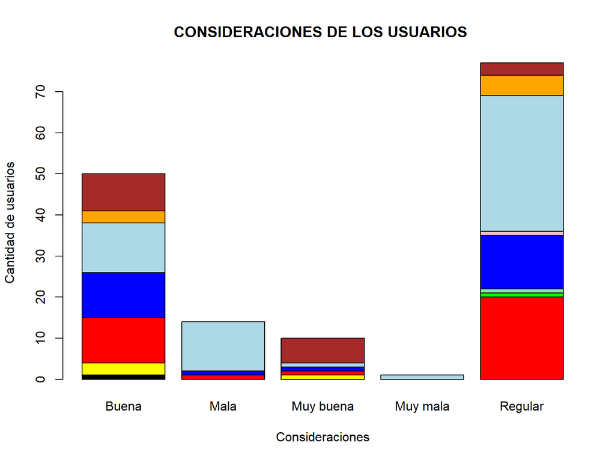

**Observaciones**

#### *Variable PAGO MENSUAL:*

En esta variable se mostrará cuánto pagan por tener el servicio a Internet.

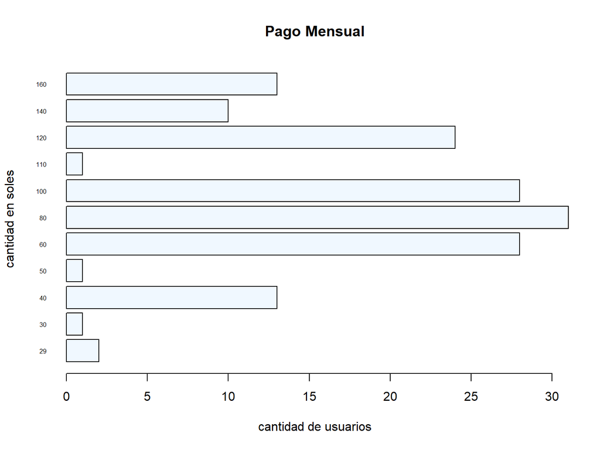

**Observaciones**

En la gráfica Se observa que los mayores usuarios pagan 80 soles, siguiéndole los precios de 60 y 100 soles por el servicio de Internet, a nuestro parecer es un precio razonable siempre y cuando te den lo que te ofrecen es decir sea un buen servicio

# Diagrama de puntos

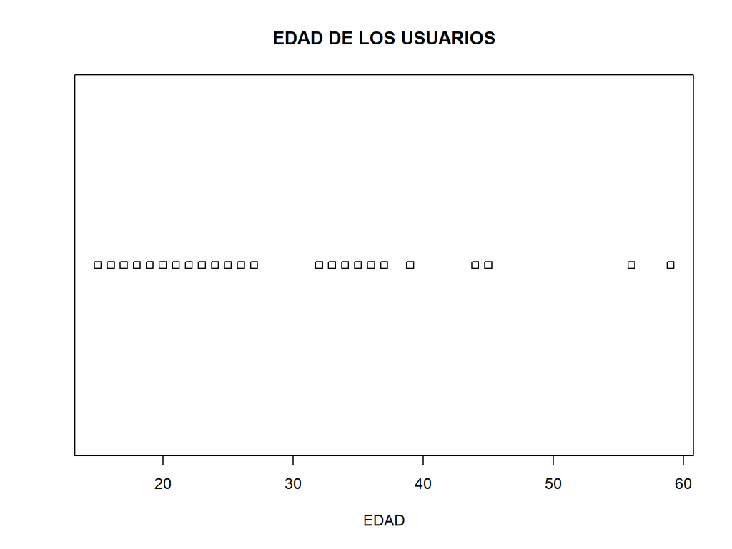

```r
EDAC<-CALIDCONEX$EDAD
stripchart(EDAC,method = "overplot", main= "EDAD DE LOS USUARIOS",xlab = "EDAD")
```

#### *Variable HORAS_DE_USO:*

En este gráfico se mostrará cuántas horas promedio al día usan el Internet nuestro encuestados.

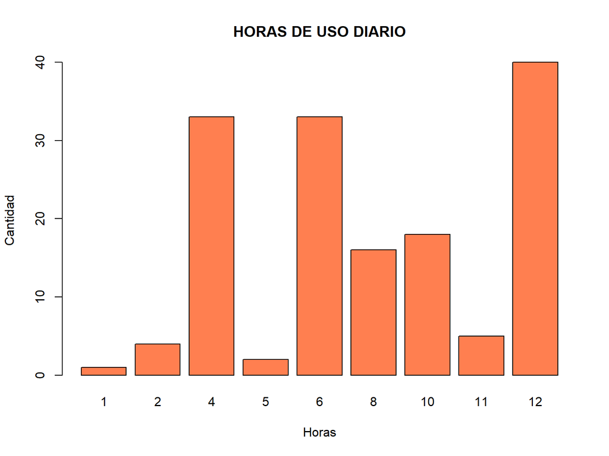

**Observaciones**

#### *Variable CONSIDERACION:*

En este gráfico se mostrará cuál es la percepción que tienen los encuestados respecto a su conexión a Internet, siendo esta desde muy mala hasta muy buena.

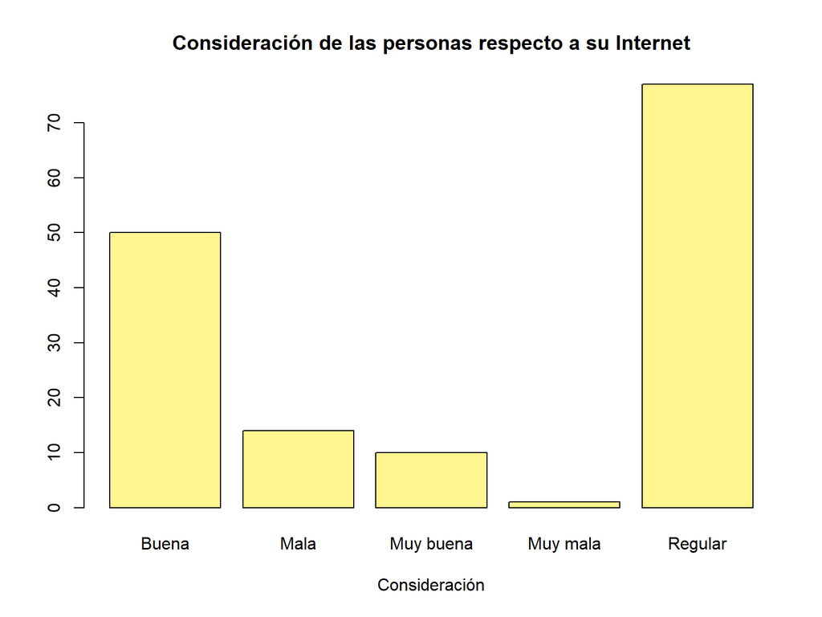

**Observaciones**

En el gráfico se puede observar que la mayoría piensa que su Internet es regular en sus hogares, esto dependerá mucho del servicio que obtengan, ya que algunas empresas son más transparentes al momento de ofrecer Internet.

#### *Variable USO:*

En este gráfico se mostrará cuales son las actividades más frecuentes para las que las personas usan el Internet.

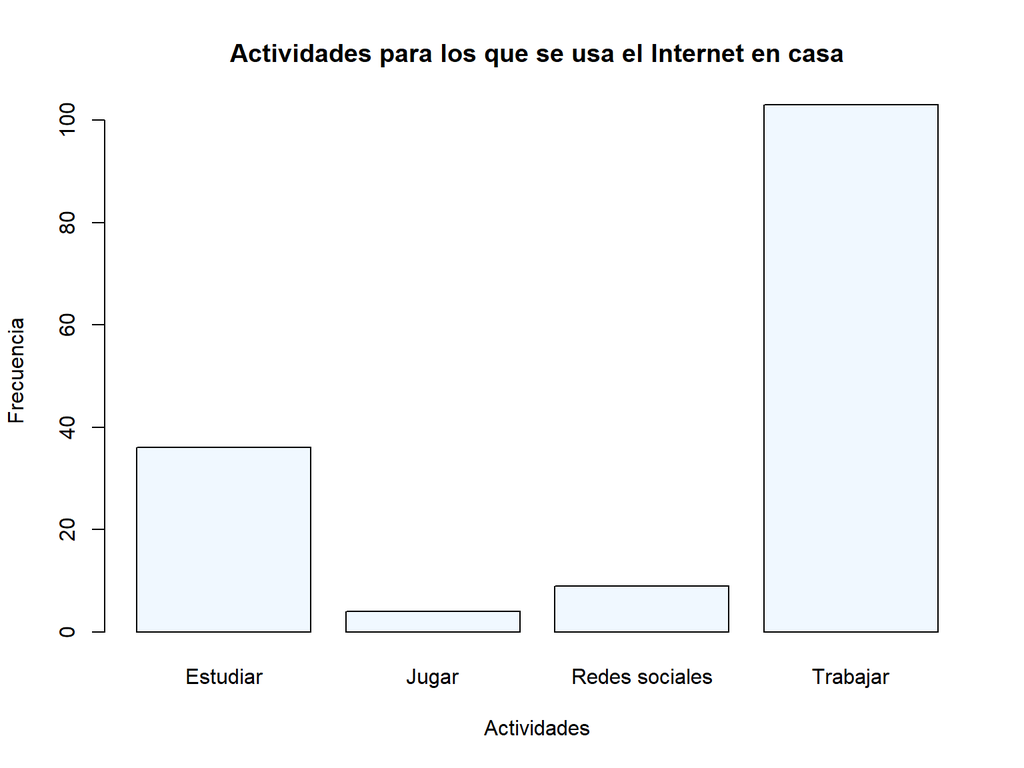

**Observaciones**

En el gráfico se puede observar que lo más frecuente es usar el Internet para trabajar, esto se debe a que desde que empezó la pandemia muchos trabajos se volvieron remotos,s por lo que las personas trabajadores se ven en la obligación de usar una laptop o computadora con WIFI permanentemente para poder cumplir su labor

#### *Variable FAMILIARES_WIFI:*

En este gráfico de barras se mostrará cuántos familiares prefieren usar WIFI y no datos móviles.

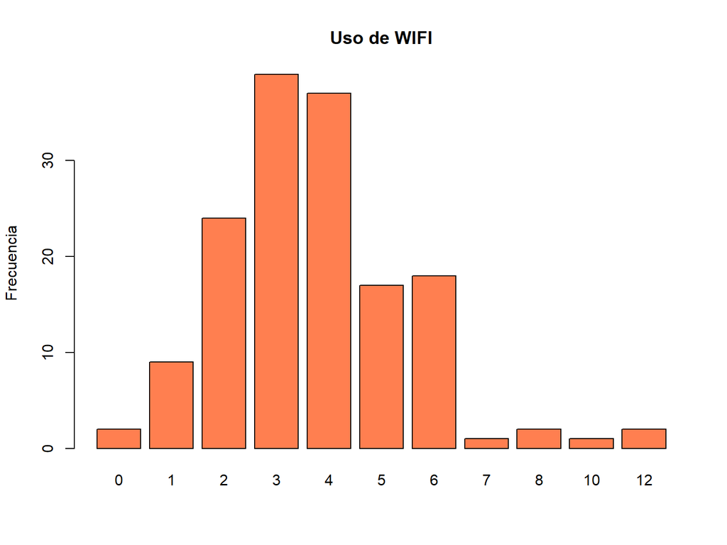

**Observaciones**

Podemos Observar en el gráfico de barras en promedio de 3 a 4 personas en cada hogar prefiere usar WIFI.

#### *Variable FAMILIARES_DATOS:*

En este gráfico de barras se mostrará cuántos familiares prefieren usar datos móviles y WIFI.

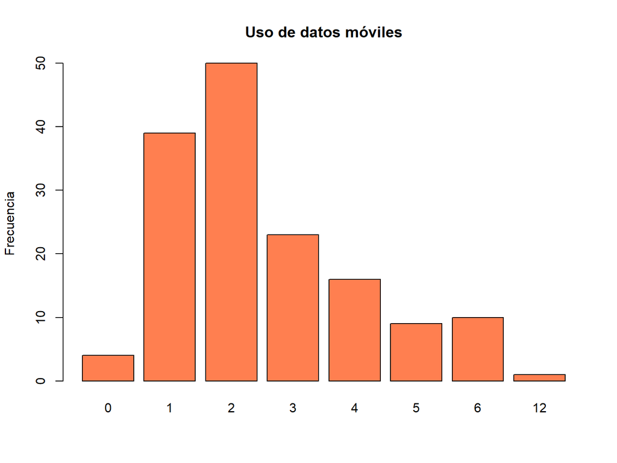

**Observaciones**

Podemos Observar en el gráfico de barras en promedio de tan sólo 2 persona en cada hogar usa datos móviles.

#### *Variable CARGA OFRECIDA :*

En este gráfico queremos ver cuánto es lo que ofrecen las empresas en MBPS.

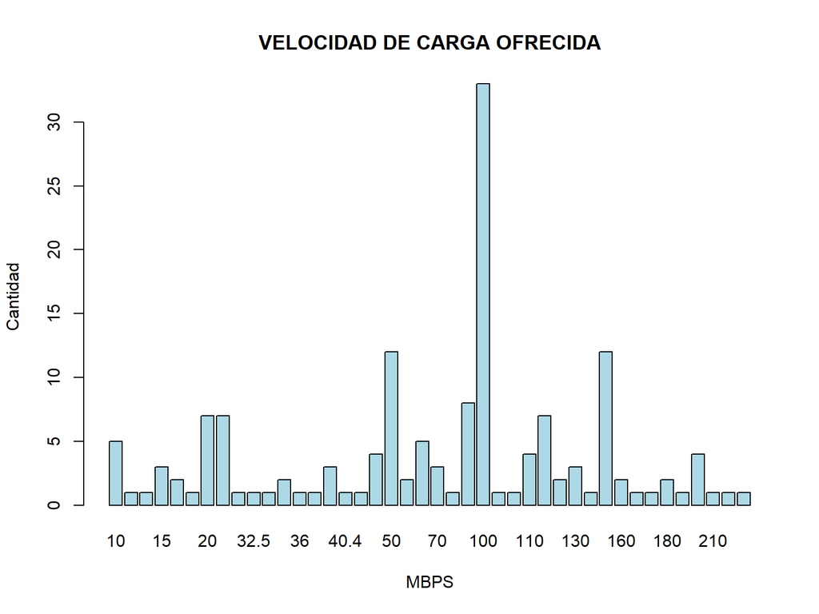

Podemos observar que la mayoría de clientes solicitan un Internet de 100 Mbps, por lo que es lo que la mayoría de personas debería de recibir.

#### *Variable CARGA REAL :*

Con este gráfico, vamos a poder comparar si lo observado con el grupo anterior es lo que realmente llega como señal a los hogares.

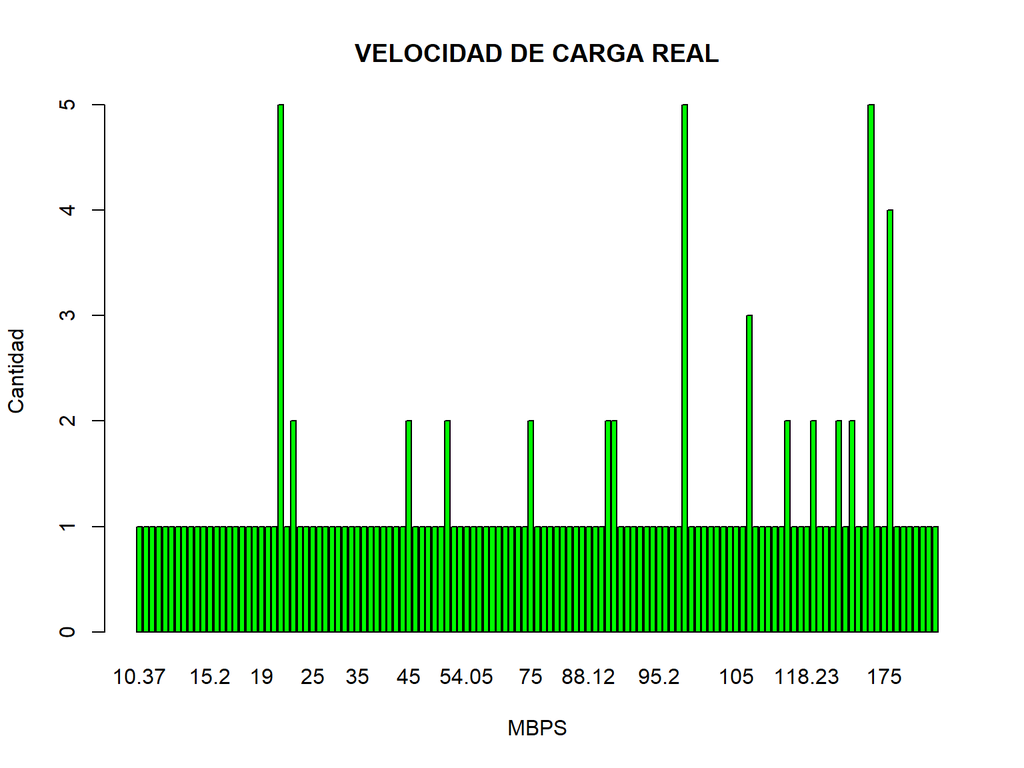

Podemos observar que la mayoría de clientes no recibe realmente lo que solicitan,a excepción de unos casos.

#### *Variable VEL_DES_OFREC :*

En este gráfico queremos ver cuántos MBPS de bajada es lo que ofrecen las empresas en MBPS.

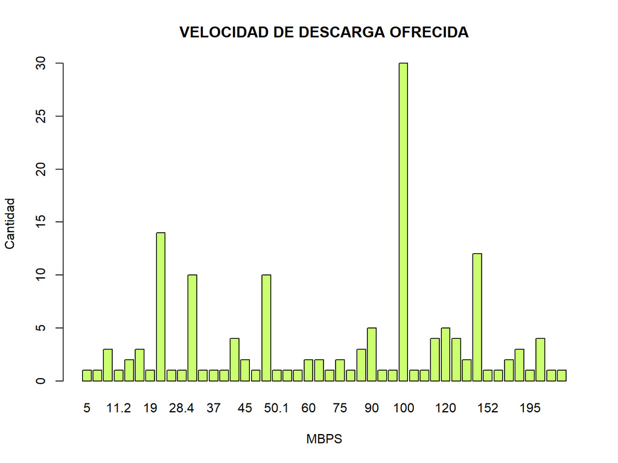

**Observaciones**

Podemos observar que la mayoría de clientes solicitan un Internet entre 100 Mbps, de bajada por lo que es lo que la mayoría de personas debería de recibir.

#### *Variable VEL_DES_REAL :*

Con este gráfico, vamos a poder comparar si lo observado en la gráfica de descarga ofrecida es lo que realmente llega como señal a los hogares.

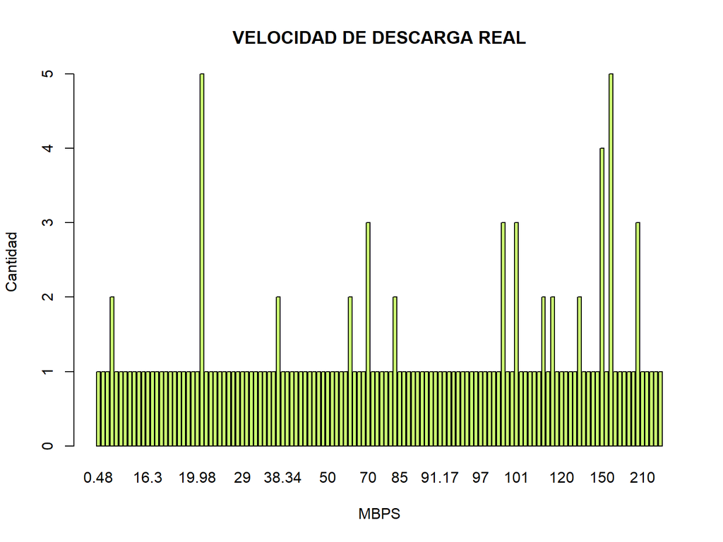

**Observaciones**

#### *Variable VEL_ENTREG:*

En esta variable se usará un gráfico de barras horizontal y se mostrará con respecto a los 4 gráficas anteriores si es que lo que las compañías dan en MBPS es mucho más o mucho menos de lo que ofrecen.

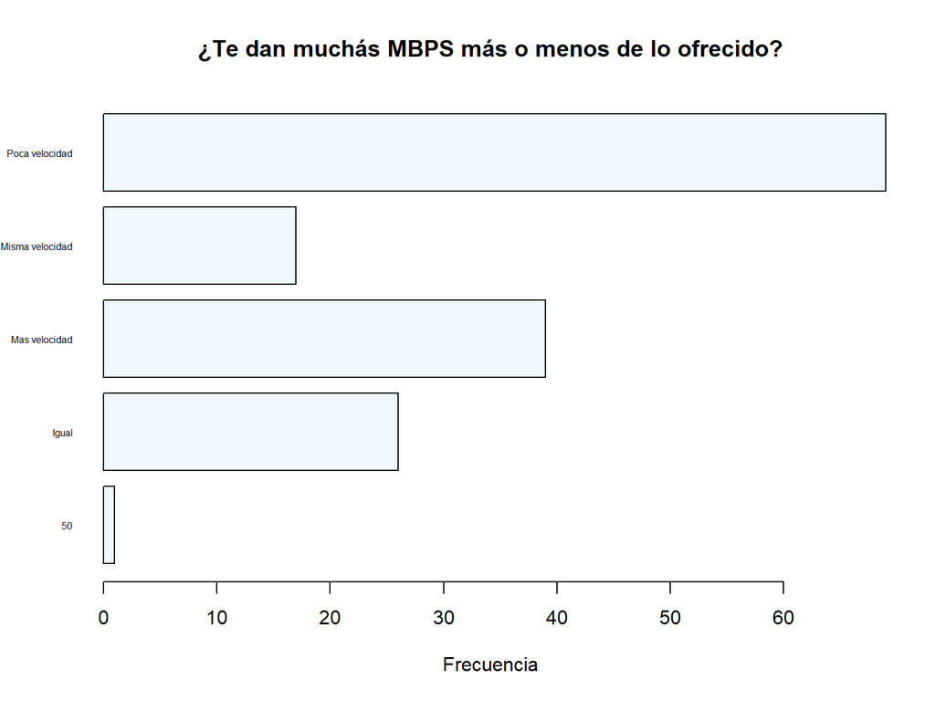

**Observaciones**

Podemos observar que la mayoría de clientes percibe que le dan poca velocidad, es decir que no cumplen con lo dicho al momento de contratar un servivicio de Internet, la diferencia es bastante clara.

#### *Variable IMPORTANCIA:*

En esta gráfica veremos cuán importante es el Internet en la vida de las personas por las horas de uso del servicio

[output not shown]

[output not shown]

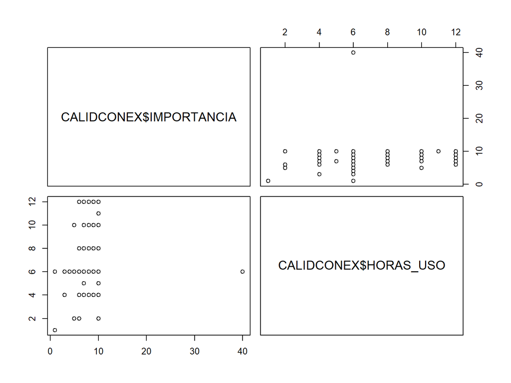

```r
cambiopago<-pairs(CALIDCONEX$IMPORTANCIA ~ CALIDCONEX$HORAS_USO)
```

```r
cor(CALIDCONEX$IMPORTANCIA,CALIDCONEX$HORAS_USO)
```

```
## [1] 0.110794
```

Observamos que la importancia con las horas de uso, no tienes una relación lineal debido a que nuestra correlación no sale cercano a la unidad.

#### *Variable PROBLEMAS:*

En esta gráfica veremos cuales son los principales problemas que se presentan al usar el Internet.

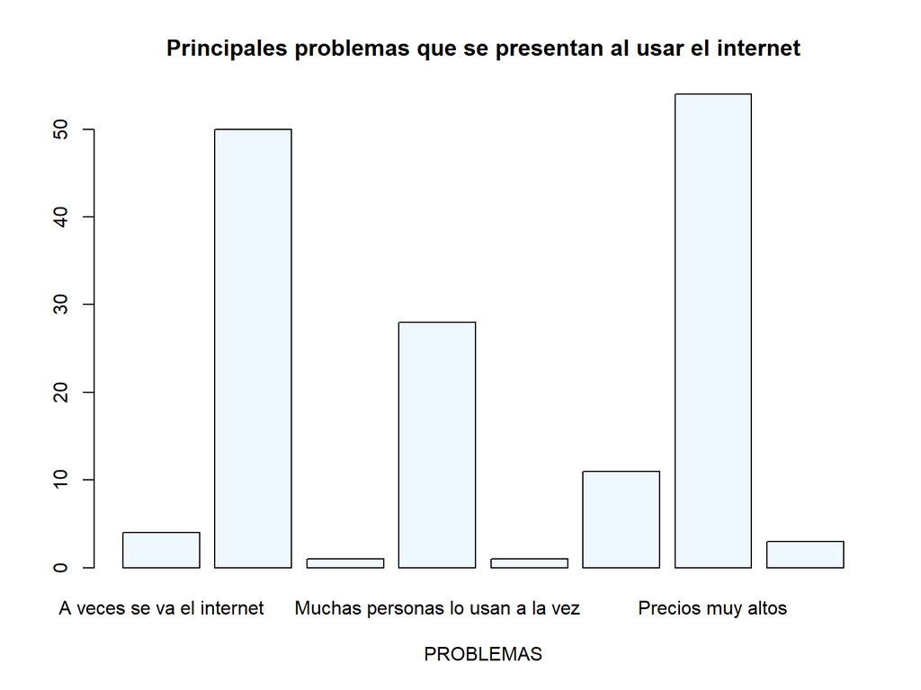

**Observaciones**

#### *Variable PELI_PERS:*

En este gráfico mostraremos cuánto demora en descargar una película en la casa del encuestado, creemos que esto nos servirá para ver que tan rápido se puede navegar en el Internet.

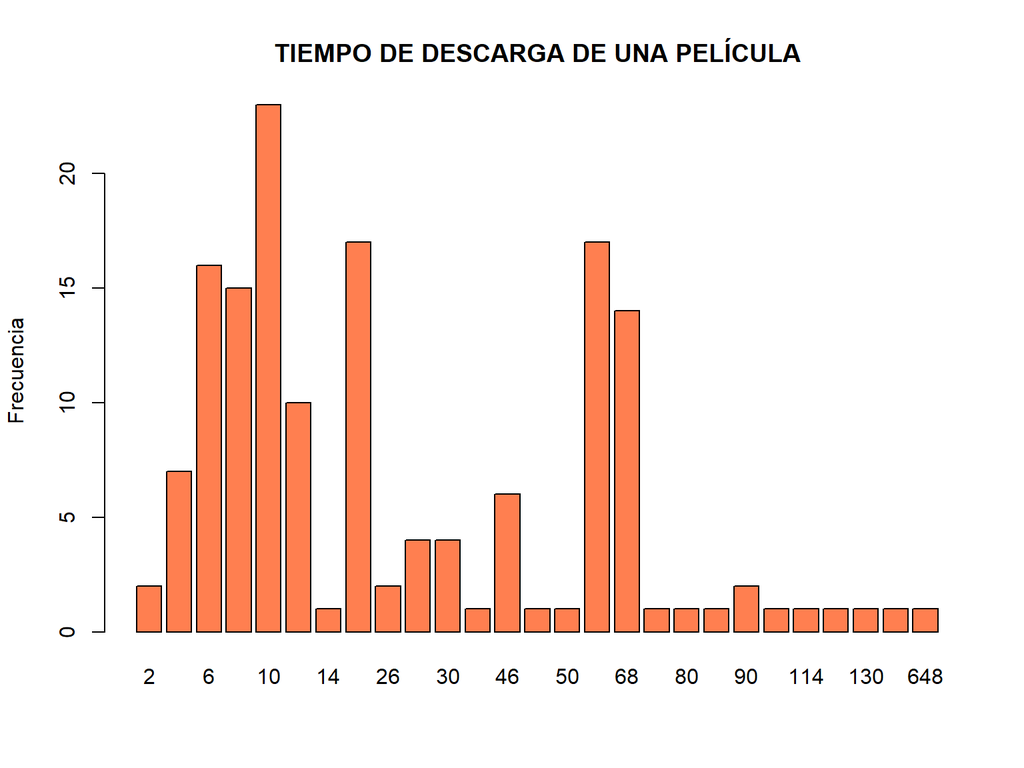

**Observaciones**

Como se puede ver demorarían en descargar una película 10 minutos y otro inclusive mas de una hora lo cual es mucho tiempo de espera

```r
mean(CALIDCONEX$PELI_PERS)
```

```
## [1] 38.63158
```

PODEMOS VER QUE EL PROMEDIO DE CUANTO TIEMPO DEMORA EN DESCARGAR UNA PELÍCULA ES ALREDEDOR DE 38 MIN.

#### *Variable PELI_VEC:*

En este gráfico mostraremos cuánto demora en descargar una película en la casa de un vecino del encuestado, creemos que esto nos servirá para ver que tan rápido se puede navegar en el Internet con otra compañía.

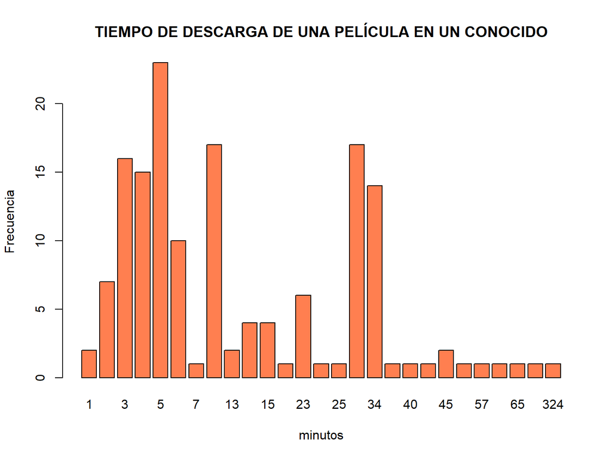

**Observaciones**

#### *Variable FALLAS_4_SEM*

En esta gráfica veremos cuántas fallas en el Internet, en promedio, se ha podido evidenciar durante las últimas 4 semanas.

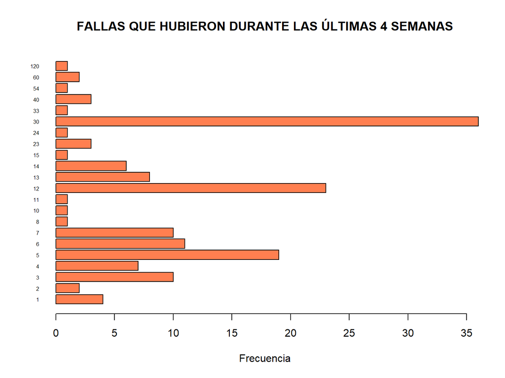

**Observaciones**

#### *Variable TIEM_ATEN*

En esta gráfica queremos presentar cuánto se demoraron en atender una llamada telefónica al reportar una falla con la conexión Internet.

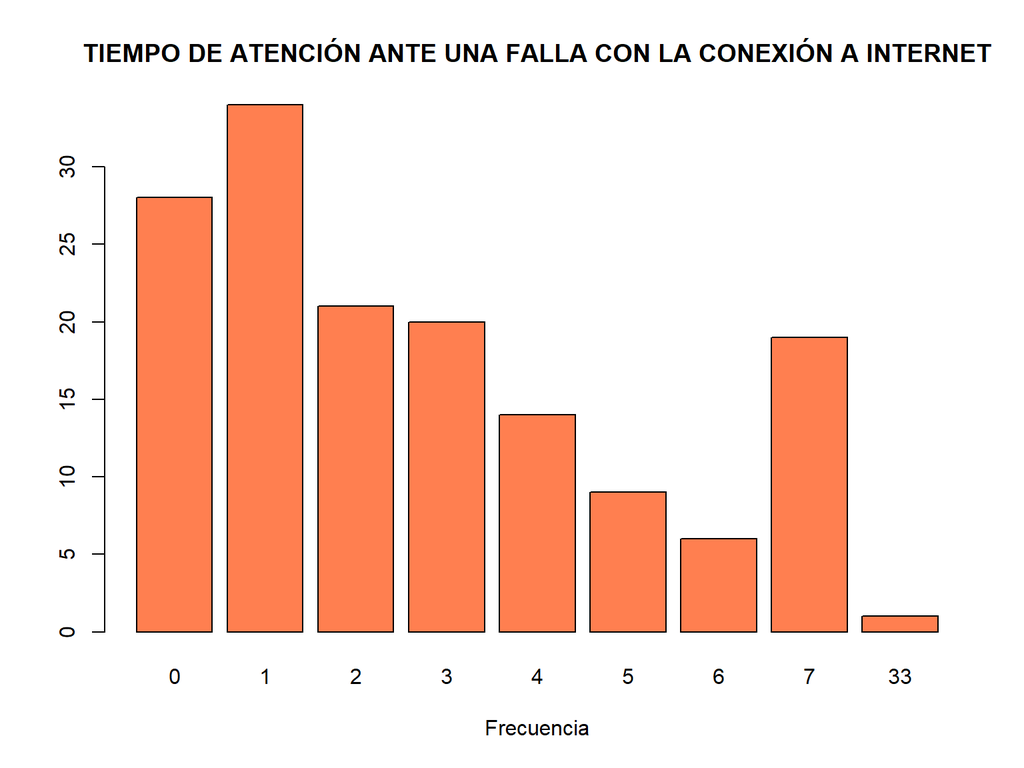

**Observaciones**

#### *Variable TIEM_ARREG*

En esta gráfica queremos presentar cuánto tiempo se tardaron en arreglar la falla técnica que se tuvo.

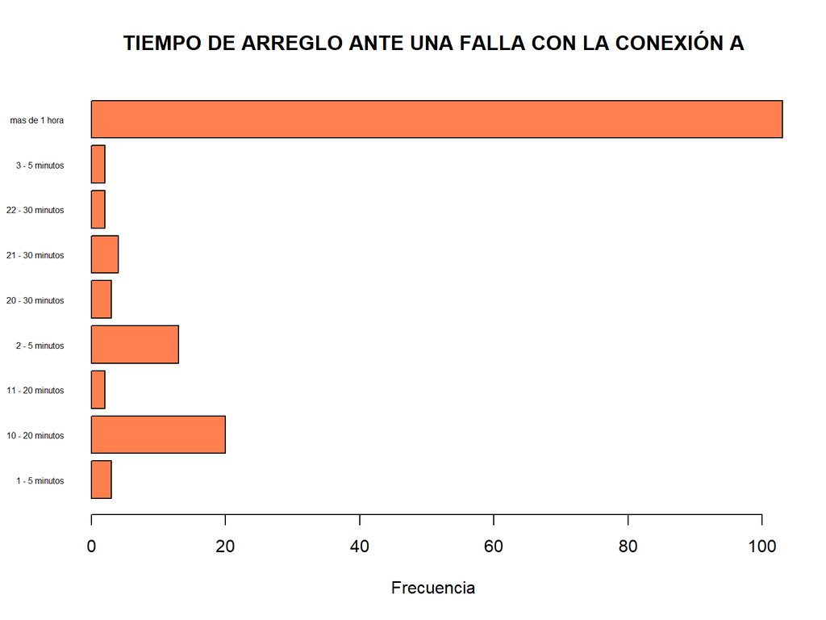

**Observaciones**

Como se puede ver la mayoría de fallas se arreglo en más de 1 hora, esto significar´´ia que los clientes se quedaron sin Internet por al menos 1 hora, en la cual pueden perder reuniones importantes.

#### *Variable CAMBIOS:*

En esta gráfica vemos cuántas veces se han tenido que cambiar de empresa buscando una mejor conexión.

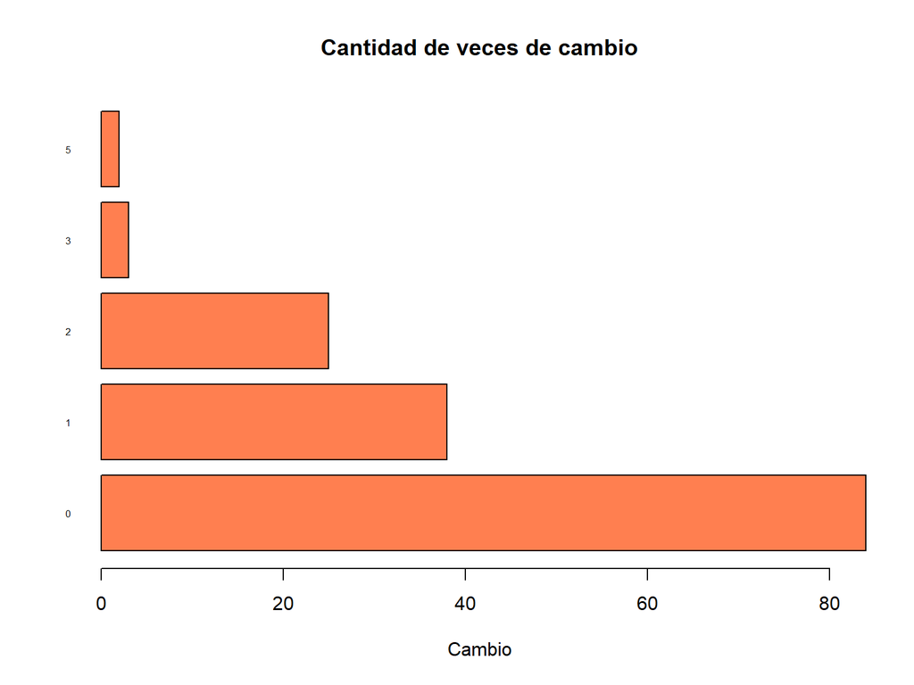

**Observaciones**

Se puede ver que a pesar de los problemas la mayoría solo se ha cambiado 1 vez o nunca en toda su vida.

# Valores para el Diagrama de cajas

#En que se usa mas el internet, segun las edades de los clientes

```r
summary(CALIDCONEX$EDAD[CALIDCONEX$USO=="Estudiar"])
```

```
##    Min. 1st Qu.  Median    Mean 3rd Qu.    Max.
##   15.00   18.75   20.50   21.44   24.00   39.00
```

```r
summary(CALIDCONEX$EDAD[CALIDCONEX$USO=="Jugar"])
```

```
##    Min. 1st Qu.  Median    Mean 3rd Qu.    Max.
##   17.00   19.25   20.00   19.75   20.50   22.00
```

```r
summary(CALIDCONEX$EDAD[CALIDCONEX$USO=="Redes sociales"])
```

```
##    Min. 1st Qu.  Median    Mean 3rd Qu.    Max.
##   16.00   18.00   19.00   19.56   22.00   25.00
```

```r
summary(CALIDCONEX$EDAD[CALIDCONEX$USO=="Trabajar"])
```

```
##    Min. 1st Qu.  Median    Mean 3rd Qu.    Max.
##   16.00   19.00   20.00   22.97   23.00   59.00
```

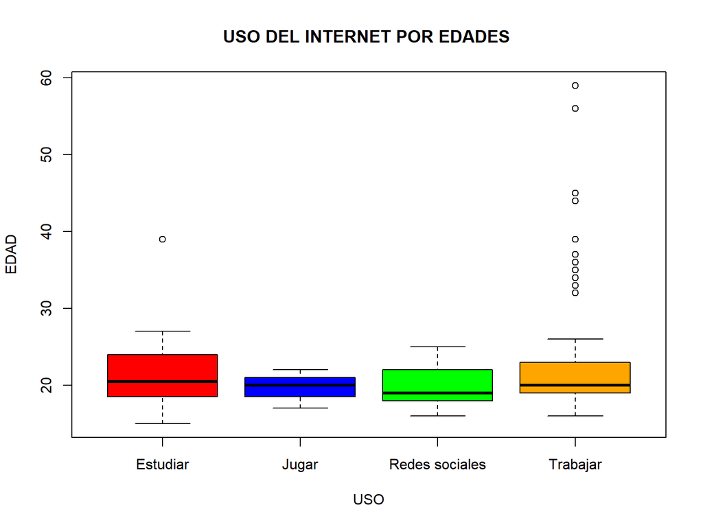

```r
boxplot(formula=CALIDCONEX$EDAD~CALIDCONEX$USO,data=CALIDCONEX,main="USO DEL INTERNET POR EDADES ",xlab="USO",ylab="EDAD",col=c("red","blue","green","orange"))
```

Podemos observar algunos valores atípicos en el uso del trabajo para las edades mayores a 30 años

También se observa que los valores de la mediana en el uso del Internet es de 19 a 20.5

# Mosaico

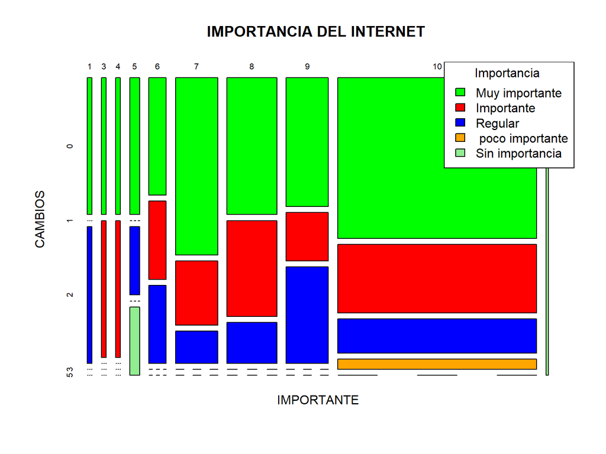

```r
pagoconsi<-table(CALIDCONEX$IMPORTANCIA,CALIDCONEX$CAMBIO)

mosaicplot(pagoconsi, main="IMPORTANCIA DEL INTERNET ",xlab="IMPORTANTE",ylab="CAMBIOS" ,col=c("green","red","blue","orange","lightgreen"))

legend(x="topright",legend=c("Muy importante", "Importante","Regular"," poco importante", "Sin importancia"),fill=c("green","red","blue","orange","lightgreen"),title="Importancia ")
```

Podemos observar que las personas que mas importante les parece el internet son los que menos cambios de proveedor realizan, tal vez se deba por tercer factores como por ejemplo, el tiempo de instalación del nuevo servicio es por ello que ya no obtan a cambiarse de proveedor.

# **4. Variables Agregadas**

#### **Variable COMPA_CARGAS**

Para esta variable queremos realizar una comparación entre las variables de carga real y carga ofrecida, para observar cuánta es la diferencia.

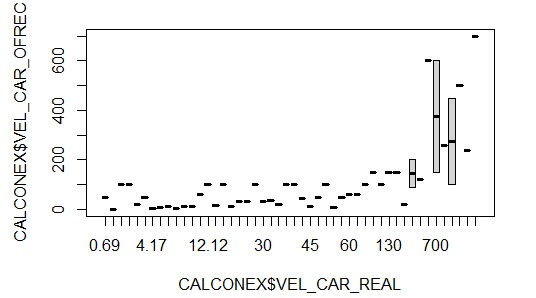

**Observaciones**

Como vemos la diferencia de la carga ofrecida y la real es notoria, por lo que esto sería una estafa de parte de las empresas a los clientes.

#### **Variable COMPA_DESCARGAS**

Para esta variable queremos realizar una comparación entre las variables de descarga real y descarga ofrecida, para observar cuánta es la diferencia.

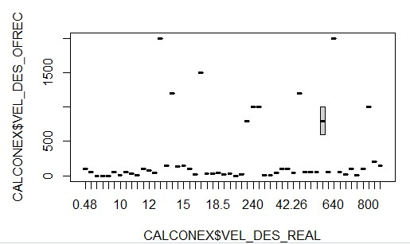

**Observaciones**

Como vemos la diferencia de la descarga ofrecida y la real es bastante notoria, por lo que esto se consideraría una estafa de parte de las empresas a los clientes.

# **5. PROBABILIDADES**

#PROBABILIDAD DE TENER UN CLIENTE QUE USE EL SERVICIO PARA TRABAJAR

```r
table(CALIDCONEX$USO)
```

```
##
##       Estudiar          Jugar Redes sociales       Trabajar
##             36              4              9            103
```

#Probabilidad de encontrar un cliente que use el internet para trabajar

```r
table(CALIDCONEX$USO=="Trabajar")/nrow(CALIDCONEX)
```

```
##
##     FALSE      TRUE
## 0.3223684 0.6776316
```

Tenemos que la probabilidad de escoger a 1 cliente que use el servicio para trabajar es de 0.6776316

##PROBABILIDAD DEL MODELO BINOMIAL

Si tomamos como muestra 30 personas, la probabilidad de que de 18 a 20 personas de esa muestra quieran un nuevo servicio de Internet es:

```r
sum(dbinom(18:20,30,0.45))
```

```
## [1] 0.06637729
```

obtenemos que la probabilidad es de 6.64% de que se cambie de servicio

#Hallamos el valor esperado numero de muestra por el porcentaje de cambio de servicio

```r
valorEsperado<-30*0.45
valorEsperado
```

```
## [1] 13.5
```

Valor esperado de 13.5

#Hallamos nuestra dispersión de datos

```r
DesviacionEstandar<-(30*0.45*0.55)
DesviacionEstandar
```

```
## [1] 7.425
```

# 6. CONCLUSIONES DE LA ENTREGA P2

# 7. FACTIBILIDAD

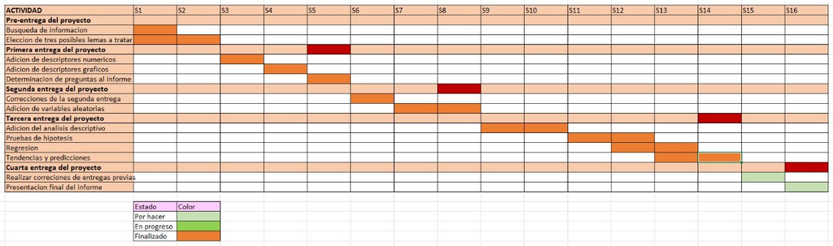

P3

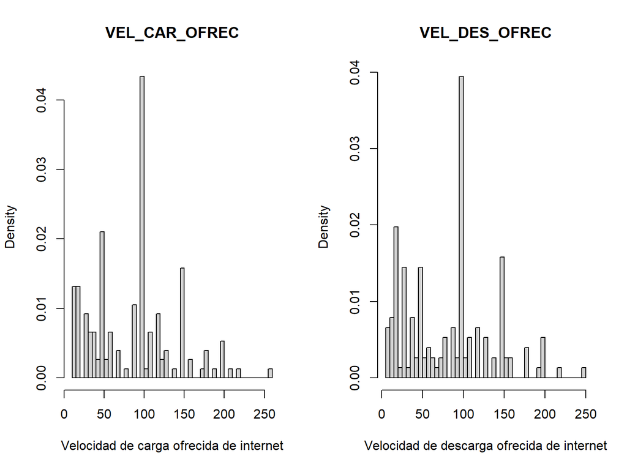

***

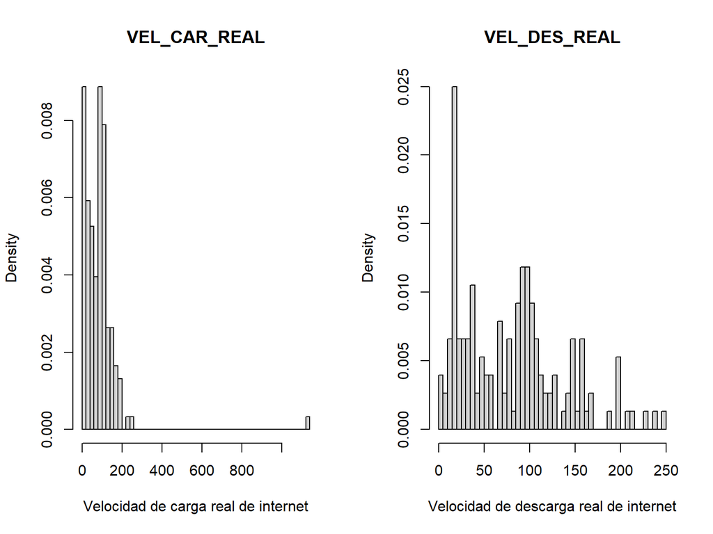

***

[output not shown]

#### **Parámetros del Estudio**: {.smaller .build}

* **Nivel de confianza:** $95 \%$

* **Significancia:** $\alpha=0.05$

* **Tamaño de la muestra:** $152$

**Variable `VELOCIDAD`**:

[output not shown]

**Variable `VELOCIDAD`**:

[output not shown]

FORMULA P +- Z * raiz(p*q/n) .

#### **Intervalos de confianza de las medias**:

***

**Intervalo de confianza para la `media`**:

[output not shown]

***

## 3. EVALUACIÓN Y PRUEBAS DE HIPÓTESIS {.build}

### Hipótesis 1

En esta hipótesis se evaluará si es que la cantidad de personas dentro de un hogar que usan el WIFI es mayor o igual a 5, instalado por un proceedor, al mismo tiempo durante el día. Para ello usaremos la prueba de t-student, unilateral izquierda, con una significancia de α = 0.05, para analizar si es que nuestra hipótesis cumple y hallar su rechazo también.

H0 : La cantidad de personas que usan el WIFI de un hogar es mayor igual a 5.

H1 : La cantidad de personas que usan el WIFI de un hogar es menor a 5.

H0 : µ ≥5

H1 : µ < 5

```r
Base <- read.csv("CALIDADDECONEXION1.csv")
summary(Base$FAMILIARES_WIFI)
```

```
##    Min. 1st Qu.  Median    Mean 3rd Qu.    Max.
##   0.000   3.000   4.000   3.763   5.000  12.000
```

```r
sd(Base$FAMILIARES_WIFI)
```

```
## [1] 1.879611
```

```r
dim(Base)
```

```
## [1] 152  26
```

```r
qnorm(0.05)
```

```
## [1] -1.644854
```

Como nuestra muestra es de 152 personas encuestadas,o sea es mayor a 30, estaremos hallando y usando el z.

Z = -8.11

### Regiones Críticas

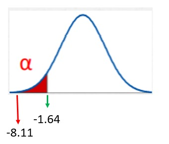

### Decisión

Como tenemos que Zcalc = -8.11 es menor a α = -1.64 deducimos que Z SI PERTENECE a la región sombreada, entonces SE RECHAZA H0.

### Hipótesis 2

En esta hipótesis estaremos indagando en la cantidad de fallas que presentan los clientes durante 4 semanas en su conectividad.Para ello usaremos la prueba de t-student, bilateral, con una significancia de α = 0.025, para analizar si es que nuestra hipótesis cumple y hallar su rechazo también.

H0 : La cantidad de fallas que presenta en 4 semanas es igual a 30.

H1 : La cantidad de fallas que presenta en 4 semanas es diferente a 30.

H0 : µ = 30

H1 : µ ≠ 30

```r
summary(Base$FALLAS_4_SEM)
```

```
##    Min. 1st Qu.  Median    Mean 3rd Qu.    Max.
##    1.00    5.00   12.00   15.95   30.00  120.00
```

```r
sd(Base$FALLAS_4_SEM)
```

```
## [1] 15.05062
```

```r
dim(Base)
```

```
## [1] 152  26
```

```r
qnorm(0.025)
```

```
## [1] -1.959964
```

Como nuestra muestra es de 152 personas encuestadas,o sea es mayor a 30, estaremos hallando y usando el z.

Z = -11.51

### Regiones Críticas

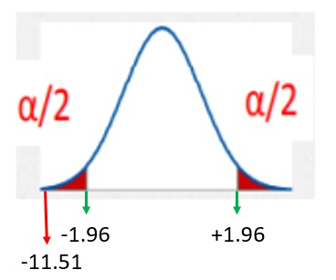

### Decisión

Como tenemos que Zcalc = -11.51 es menor a α = -1.96 deducimos que Z SI PERTENECE a la región sombreada, entonces si RECHAZO H0.

### Conclusión

Con el 0.05 de significancia, hay evidencias para rechazar H0, entonces NO se puede considerar que el promedio de cantidad de fallas que se presentan en 4 semanas es de 30 en cada cliente.

### Hipótesis 3

En esta hipótesis estaremos evaluando si es que el tiempo en que se demora en descargar una película en casa de igual a 30 minutos. Para ello usaremos la prueba de t-student, bilateral, con una significancia de α = 0.025, para analizar si es que nuestra hipótesis cumple y hallar su rechazo también.

H0 : El tiempo promedio que se demora en descargar una película en tu casa es igual a 30 minutos.

H1 : El tiempo promedio que se demora en descargar una película en tu casa es diferente a 30 minutos.

H0 : µ = 30

H1 : µ ≠ 30 Para la evaluación de hipótesis se considerará una significancia 5%(α=0.025).

```r
Base <- read.csv("CALIDADDECONEXION1.csv")
summary(Base$PELI_PERS)
```

```
##    Min. 1st Qu.  Median    Mean 3rd Qu.    Max.
##    2.00    8.00   24.00   38.63   60.00  648.00
```

```r
sd(Base$PELI_PERS)
```

```
## [1] 75.91889
```

```r
dim(Base)
```

```
## [1] 152  26
```

```r
qnorm(0.025)
```

```
## [1] -1.959964
```

Como nuestra muestra es 152,o sea es mayor a 30, podemos utilizar el Z

Z=1.40

### Regiones Críticas

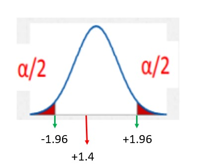

### Decisión

Como Zcalc = 1.40 no PERTENECE a la región sombreada, entonces no RECHAZO H0.

### Conclusión

Con el 0.05 de significación, hay evidencia para no rechazar H0 entonces se puede considerar que el promedio de tiempo es igual a 30 minutos.

### Hipótesis 4

En esta hipótesis planteamos si es que la velocidad promedio real calculado a través del speedtest es mayor igual a 50 MBPS. Para ello usaremos la prueba de t-student, unilateral izquierda, con una significancia de α = 0.05, para analizar si es que nuestra hipótesis cumple y hallar su rechazo también.

H0 : La velocidad promedio real medida a través de speedtest es mayor igual a 50.

H1 : La velocidad promedio real medida a través de speedtest es menor a 50

H0 : µ ≥ 50

H1 : µ < 50

```r
summary(Base$VEL_CAR_REAL)
```

```
##    Min. 1st Qu.  Median    Mean 3rd Qu.    Max.
##   10.37   33.95   85.73   87.08  110.42 1130.00
```

```r
sd(Base$VEL_CAR_REAL)
```

```
## [1] 99.82345
```

```r
dim(Base)
```

```
## [1] 152  26
```

```r
qnorm(0.05)
```

```
## [1] -1.644854
```

Como nuestra muestra es 152,o sea es mayor a 30, podemos utilizar el Z= 4.58

### Regiones Críticas

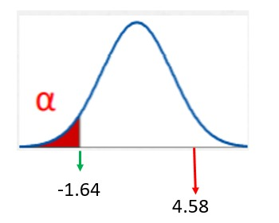

### Decisión

Como Zcalc = 4.58 NO PERTENECE a la región sombreada, entonces NO RECHAZO H0.

### Conclusión